# Northcott Medulloblastoma: PLIER

**CCDL 2018**

In this notebook, we’ll use a method called Pathway-Level Information Extractor (PLIER) ([Mao, et al. *bioRxiv.* 2017.](https://doi.org/10.1101/116061)).

We like PLIER for a few reasons:

- It is a matrix factorization approach. That means we can get a low-dimensional representation of our data. Specifically, PLIER learns correlated patterns of expression in our data or latent variables (LVs).
- It includes penalties such that *some* of the LVs will align with gene sets that we give it, so it’s excellent for biological discovery.
- The authors demonstrated that it performs favorably with regard to estimating proportion of immune cells in a sample as compared to other methods.
- Because not *all* LVs align with the gene sets we input, some of them capture unwanted technical variation. In our experience with the method, it does this quite well.

## Libraries and functions

```r
# PLIER library
library(PLIER)
```

```r
# magrittr pipe
`%>%` <- dplyr::`%>%`
```

## Directories and files

```r
# directory for the data
data_dir <- file.path("data", "GSE37382")
results_dir <- "results"
if (!dir.exists(results_dir)) {
  dir.create(results_dir, recursive = TRUE)
}
# directory where we will save any plots
plots_dir <- "plots"
if (!dir.exists(plots_dir)) {
  dir.create(plots_dir, recursive = TRUE)
}
# directory where we'll put the PLIER model
model_dir <- "models"
if (!dir.exists(model_dir)) {
  dir.create(model_dir, recursive = TRUE)
}
# expression data that we prepped in the first notebook
exprs_file <- file.path(data_dir, "GSE37382_SCAN_symbol_mean_agg.tsv")
```

**Output**

```r
# plier model output
plier_file <- file.path(model_dir, "GSE37382_PLIER_model.RDS")
# B matrix heatmap
b_heatmap_file <- file.path(plots_dir, "GSE37382_B_heatmap_significant.pdf")
```

## Read in expression data and prep for use with PLIER

```r
exprs_df <- data.table::fread(exprs_file, data.table = FALSE)
```

We’ll need a matrix of expression data where the `rownames` are the gene symbols.

```r
exprs_mat <- as.matrix(tibble::column_to_rownames(exprs_df, "SYMBOL"))
exprs_mat[1:5, 1:5]
```

```
          GSM917011   GSM917014  GSM917018   GSM917016   GSM917015
TSPAN6    1.2513634  1.11221276  1.4949001  1.27573046  1.11687352
TNMD     -0.0820530 -0.09228043 -0.1366823 -0.07242942 -0.05649676
DPM1      1.8669135  1.92997492  2.2491578  1.97004231  2.17983881
SCYL3     0.8664711  0.91796804  1.0584101  0.86060887  0.94762607
C1orf112  0.8421662  0.89395826  0.8461293  0.60098364  0.96107633
```

## Run PLIER

We’ll set a seed using `set.seed`. This makes our results reproducible.

```r
seed <- 12345
set.seed(seed)
```

### Gene sets for PLIER

The PLIER package comes with gene sets. We’ll use the ones associated with immune cell types (`bloodCellMarkersIRISDMAP` and `svmMarkers`) and the `canonicalPathways` (e.g., KEGG, REACTOME). You can also use your own custom gene sets if desired.

```r
# load PLIER pathway and cell type data
data(bloodCellMarkersIRISDMAP)
data(svmMarkers)
data(canonicalPathways)
```

We’ll use PLIER built in functions to prepare the gene sets for use.

```r
# combine the pathway data from PLIER
all_paths <- PLIER::combinePaths(bloodCellMarkersIRISDMAP, svmMarkers,
                                 canonicalPathways)
# what genes are common to the pathway data and the expression matrix
cm_genes <- PLIER::commonRows(all_paths, exprs_mat)
```

### Row normalize

And a built-in function to row normalize the expression data. This is z-scoring the expression values for each gene.

```r
# row normalize -- z-scoring the genes
exprs_norm <- PLIER::rowNorm(exprs_mat)
```

Let’s compare the expression values from the first row (gene) before and after the normalization.

*Before*

```r
summary(exprs_mat[1, ])
```

```
   Min. 1st Qu.  Median    Mean 3rd Qu.    Max.
 0.2951  0.7237  0.8617  0.8697  0.9810  1.9430
```

```r
var(exprs_mat[1, ])
```

```
[1] 0.05426503
```

*After*

```r
summary(exprs_norm[1, ])
```

```
    Min.  1st Qu.   Median     Mean  3rd Qu.     Max.
-2.46700 -0.62676 -0.03476  0.00000  0.47738  4.60734
```

```r
var(exprs_norm[1, ])
```

```
[1] 1
```

### Set k

To define the number of latent variables (`k`), we’ll need to first determine the number of “significant principal components” using a built-in PLIER function.

```r
# what should we set the minimum k parameter to in PLIER? estimate the number
# of PC for the SVD decomposition
set_k <- PLIER::num.pc(exprs_norm[cm_genes, ])
```

### PLIER

Okay, now we’re ready to run PLIER! The authors recommend using the number of significant PCs + 30% for the `k` argument.

```r
# PLIER main function + return results
plier_results <- PLIER::PLIER(exprs_norm[cm_genes, ], all_paths[cm_genes, ],
                              k = round((set_k + set_k * 0.3), 0), trace = TRUE)
```

```
Removing 2 pathways with too few genesComputing SVD
Done
```

```
[1] 72.72086
[1] "L2 is set to 72.7208604774316"
[1] "L1 is set to 36.3604302387158"
```

```
errorY (SVD based:best possible) = 0.2386
iter1 errorY= 0.9852, Bdiff= 10050, Bkappa=53.01
iter2 errorY= 0.6522, Bdiff= 0.7033, Bkappa=52
iter3 errorY= 0.5376, Bdiff= 0.08188, Bkappa=36.55
iter4 errorY= 0.5214, Bdiff= 0.02152, Bkappa=31.83
iter5 errorY= 0.516, Bdiff= 0.01224, Bkappa=25.99
iter6 errorY= 0.5123, Bdiff= 0.009478, Bkappa=26.49
iter7 errorY= 0.5087, Bdiff= 0.007954, Bkappa=26.79
iter8 errorY= 0.5053, Bdiff= 0.006802, Bkappa=29.26
iter9 errorY= 0.5021, Bdiff= 0.005851, Bkappa=32.73
iter10 errorY= 0.4993, Bdiff= 0.005004, Bkappa=37.42
iter11 errorY= 0.497, Bdiff= 0.004224, Bkappa=41.33
iter12 errorY= 0.4951, Bdiff= 0.00356, Bkappa=46.35
iter13 errorY= 0.4934, Bdiff= 0.003034, Bkappa=50.78
iter14 errorY= 0.4921, Bdiff= 0.002629, Bkappa=52.37
iter15 errorY= 0.4909, Bdiff= 0.002307, Bkappa=48.36
iter16 errorY= 0.4899, Bdiff= 0.00204, Bkappa=41.24
iter17 errorY= 0.489, Bdiff= 0.001807, Bkappa=42.32
iter18 errorY= 0.4882, Bdiff= 0.001611, Bkappa=37.01
iter19 errorY= 0.4875, Bdiff= 0.001441, Bkappa=39.57
Updating L3, current fraction= 0, target=0.7
L3 is set to 0.005372 in 11 iterations
iter20 errorY= 0.4854, prior information ratio= 0.04, Bdiff= 0.001458, Bkappa=40.24;pos. col. U=40
iter21 errorY= 0.4843, prior information ratio= 0.05, Bdiff= 0.001349, Bkappa=43.41;pos. col. U=40
iter22 errorY= 0.4835, prior information ratio= 0.05, Bdiff= 0.001224, Bkappa=45.38;pos. col. U=40
iter23 errorY= 0.4829, prior information ratio= 0.05, Bdiff= 0.001101, Bkappa=45.77;pos. col. U=39
iter24 errorY= 0.4823, prior information ratio= 0.06, Bdiff= 0.0009947, Bkappa=49.14;pos. col. U=38
iter25 errorY= 0.4818, prior information ratio= 0.06, Bdiff= 0.000903, Bkappa=49.61;pos. col. U=36
iter26 errorY= 0.4813, prior information ratio= 0.06, Bdiff= 0.0008255, Bkappa=50.31;pos. col. U=35
iter27 errorY= 0.4809, prior information ratio= 0.06, Bdiff= 0.0007602, Bkappa=51.74;pos. col. U=34
iter28 errorY= 0.4805, prior information ratio= 0.06, Bdiff= 0.0007052, Bkappa=50.29;pos. col. U=34
iter29 errorY= 0.4801, prior information ratio= 0.06, Bdiff= 0.0006592, Bkappa=59.96;pos. col. U=35
iter30 errorY= 0.4798, prior information ratio= 0.06, Bdiff= 0.0006207, Bkappa=61.11;pos. col. U=36
iter31 errorY= 0.4795, prior information ratio= 0.06, Bdiff= 0.0005876, Bkappa=62.36;pos. col. U=36
iter32 errorY= 0.4792, prior information ratio= 0.06, Bdiff= 0.00056, Bkappa=63.73;pos. col. U=35
iter33 errorY= 0.4789, prior information ratio= 0.06, Bdiff= 0.0005368, Bkappa=65.26;pos. col. U=35
iter34 errorY= 0.4787, prior information ratio= 0.06, Bdiff= 0.0005165, Bkappa=67.19;pos. col. U=35
iter35 errorY= 0.4784, prior information ratio= 0.06, Bdiff= 0.0004985, Bkappa=67.98;pos. col. U=36
iter36 errorY= 0.4782, prior information ratio= 0.06, Bdiff= 0.0004827, Bkappa=68.15;pos. col. U=36
iter37 errorY= 0.478, prior information ratio= 0.06, Bdiff= 0.0004676, Bkappa=65.89;pos. col. U=35
```

[output cut: 220 more lines]

```
iter235 errorY= 0.4706, prior information ratio= 0.06, Bdiff= 3.855e-05, Bkappa=33.99;pos. col. U=40
iter236 errorY= 0.4705, prior information ratio= 0.06, Bdiff= 4.236e-05, Bkappa=32.18;pos. col. U=40
Bdiff is not decreasing
iter237 errorY= 0.4705, prior information ratio= 0.06, Bdiff= 4.694e-05, Bkappa=30.8;pos. col. U=40
Bdiff is not decreasing
iter238 errorY= 0.4704, prior information ratio= 0.06, Bdiff= 5.16e-05, Bkappa=29.8;pos. col. U=40
Bdiff is not decreasing
iter239 errorY= 0.4703, prior information ratio= 0.06, Bdiff= 5.53e-05, Bkappa=29.09;pos. col. U=40
Bdiff is not decreasing
Updating L3, current fraction= 0.6897, target=0.7
L3 not changed
iter240 errorY= 0.4702, prior information ratio= 0.06, Bdiff= 5.716e-05, Bkappa=28.59;pos. col. U=40
Bdiff is not decreasing
converged at  iteration 240 Bdiff is not decreasing
There are 22  LVs with AUC>0.70
```

Let’s save this to our model directory

```r
readr::write_rds(plier_results, path = plier_file)
```

## Exploring the PLIER model

`plotU` will give us insight into what pathways or cell types were captured by the latent variables from the model.

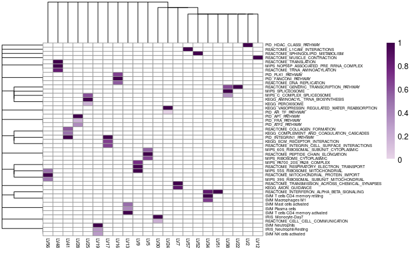

```r
PLIER::plotU(plier_results, fontsize_col = 6, fontsize_row = 5)
```

We can save this as a PDF in our plots directory

```r
u_plot_file <- file.path(plots_dir, "GSE37382_U_plot.pdf")
pdf(u_plot_file)
PLIER::plotU(plier_results, fontsize_col = 6, fontsize_row = 5)
dev.off()
```

### What LVs have pathways or cell types associated with them?

PLIER returns a summary `data.frame` that will give us a bit more information.

```r
plier_summary_df <- plier_results$summary
plier_summary_df
```

| pathway | LV index | AUC | p-value | FDR |
| --- | --- | --- | --- | --- |
| PID_IFNGPATHWAY | 1 | 0.5939095 | 1.710536e-01 | 2.459779e-01 |
| MIPS_MEDIATOR_COMPLEX | 2 | 0.3031622 | 9.479962e-01 | 9.479962e-01 |
| KEGG_LYSINE_DEGRADATION | 2 | 0.4979851 | 5.078954e-01 | 5.891586e-01 |
| SIG_CD40PATHWAYMAP | 2 | 0.6809472 | 5.080260e-02 | 9.608318e-02 |
| REACTOME_ACTIVATION_OF_CHAPERONE_GENES_BY_XBP1S | 2 | 0.6038839 | 1.550260e-01 | 2.289140e-01 |
| MIPS_SPLICEOSOME | 2 | 0.5924833 | 4.405138e-02 | 8.766819e-02 |
| KEGG_NOTCH_SIGNALING_PATHWAY | 2 | 0.6629531 | 4.433793e-02 | 8.766819e-02 |
| PID_LKB1_PATHWAY | 2 | 0.5455419 | 3.171656e-01 | 4.028234e-01 |
| PID_HDAC_CLASSI_PATHWAY | 2 | 0.7498557 | 6.950549e-04 | 3.019971e-03 |
| REACTOME_CLASS_B_2_SECRETIN_FAMILY_RECEPTORS | 3 | 0.5003837 | 4.983394e-01 | 5.891586e-01 |

[output cut: 164 more lines]

We can filter this `data.frame` based on significance of associations. We’ll use `FDR < 0.05`, where `FDR` is the [False Discovery Rate](https://en.wikipedia.org/wiki/False_discovery_rate).  
(For further explanation of the False Discovery Rate method, here’s an [awesome StatQuest video](https://www.youtube.com/watch?v=K8LQSvtjcEo).)

```r
plier_summary_df %>%
  dplyr::filter(FDR < 0.05)
```

| pathway | LV index | AUC | p-value | FDR |
| --- | --- | --- | --- | --- |
| PID_HDAC_CLASSI_PATHWAY | 2 | 0.7498557 | 6.950549e-04 | 3.019971e-03 |
| REACTOME_3_UTR_MEDIATED_TRANSLATIONAL_REGULATION | 5 | 0.9139003 | 1.771477e-13 | 3.852962e-12 |
| REACTOME_PEPTIDE_CHAIN_ELONGATION | 5 | 0.9988290 | 5.629512e-15 | 1.399336e-13 |
| KEGG_RIBOSOME | 5 | 0.9984442 | 6.853027e-16 | 2.721955e-14 |
| MIPS_RIBOSOME_CYTOPLASMIC | 5 | 0.9995161 | 5.274713e-15 | 1.399336e-13 |
| MIPS_60S_RIBOSOMAL_SUBUNIT_CYTOPLASMIC | 5 | 0.9962757 | 3.395714e-09 | 5.371403e-08 |
| REACTOME_TRANSLATION | 5 | 0.8032014 | 1.724114e-10 | 3.333287e-09 |
| REACTOME_TRANSMISSION_ACROSS_CHEMICAL_SYNAPSES | 7 | 0.6121515 | 2.130408e-02 | 4.752449e-02 |
| KEGG_AXON_GUIDANCE | 7 | 0.6222602 | 2.003373e-02 | 4.527102e-02 |
| REACTOME_MITOCHONDRIAL_PROTEIN_IMPORT | 9 | 0.7801913 | 2.556585e-03 | 8.554728e-03 |

[output cut: 69 more lines]

We can also sort by AUC ([Area Under the ROC Curve](https://towardsdatascience.com/understanding-auc-roc-curve-68b2303cc9c5)) values after filtering.

```r
plier_summary_df %>%
  dplyr::filter(FDR < 0.05) %>%
  dplyr::arrange(dplyr::desc(AUC))
```

| pathway | LV index | AUC | p-value | FDR |
| --- | --- | --- | --- | --- |
| MIPS_RIBOSOME_CYTOPLASMIC | 5 | 0.9995161 | 5.274713e-15 | 1.399336e-13 |
| REACTOME_PEPTIDE_CHAIN_ELONGATION | 5 | 0.9988290 | 5.629512e-15 | 1.399336e-13 |
| KEGG_RIBOSOME | 5 | 0.9984442 | 6.853027e-16 | 2.721955e-14 |
| MIPS_60S_RIBOSOMAL_SUBUNIT_CYTOPLASMIC | 5 | 0.9962757 | 3.395714e-09 | 5.371403e-08 |
| PID_FRA_PATHWAY | 28 | 0.9610520 | 4.869547e-05 | 3.389205e-04 |
| SVM Neutrophils | 19 | 0.9323747 | 2.196673e-07 | 2.940163e-06 |
| REACTOME_DEPOSITION_OF_NEW_CENPA_CONTAINING_NUCLEOSOMES_AT_THE_CENTROMERE | 16 | 0.9242380 | 3.039004e-05 | 2.358530e-04 |
| PID_INTEGRIN1_PATHWAY | 17 | 0.9139582 | 3.547999e-06 | 3.429732e-05 |
| REACTOME_3_UTR_MEDIATED_TRANSLATIONAL_REGULATION | 5 | 0.9139003 | 1.771477e-13 | 3.852962e-12 |
| REACTOME_MEIOTIC_RECOMBINATION | 16 | 0.8997686 | 2.682276e-05 | 2.222457e-04 |

[output cut: 69 more lines]

We can see very strong associations between the ribosome and LV5, for example.

Let’s make a heatmap of the LV expression values, which can be found in `plier_results$B`

```r
plier_results$B[1:10, 1:5]
```

```
                                       GSM917011   GSM917014  GSM917018  GSM917016   GSM917015
LV 1                                -0.344099860 -0.24209022 -0.5194299 -0.3448512 -0.56742008
2,PID_HDAC_CLASSI_PATHWAY           -1.155933091 -0.55485673 -1.2741369 -0.9212907 -0.97850805
LV 3                                -0.001332052 -0.50961280 -0.1315516 -0.2064012 -0.07479859
LV 4                                -0.345429940 -0.34981219 -0.3499461 -0.1936866 -0.38738059
5,REACTOME_PEPTIDE_CHAIN_ELONGATION  0.320689693  0.68243133  0.6255710  0.2673414  0.67356207
LV 6                                -0.108863087 -0.11226238 -0.3613476  0.1498125 -0.02522558
LV 7                                 0.040336394  0.01706719 -0.4275816  0.5391836 -0.20576920
LV 8                                -0.250607232 -0.48470566 -0.1039304 -0.3916604 -0.68233575
9,MIPS_55S_RIBOSOME_MITOCHONDRIAL    0.498291446  1.37996923  0.8995910  0.9651698  0.05034523
LV 10                               -0.600439540 -0.87531144 -0.8167369 -0.7134312 -0.92854489
```

To make visualization a bit easier, let’s limit our heatmap to only those LVs with a significant association with a gene set using the same FDR cutoff as above and `AUC > 0.75`

```r
# first, let's subset summary to only the significant associations like above
sig_summary_df <- plier_summary_df %>%
  dplyr::filter(FDR < 0.05,
                AUC > 0.75)
# the index of the LVs we want will now be in the `LV index` column of this
# data.frame -- but if an LV is associated with multiple gene sets we'll get
# duplicate values. unique helps us with that.
sig_index <- unique(sig_summary_df$`LV index`)
```

Let’s get the LV expression value matrix out of `plier_results`

```r
b_matrix <- plier_results$B
sig_b_matrix <- b_matrix[as.integer(sig_index), ]
```

Let’s make the heatmap itself

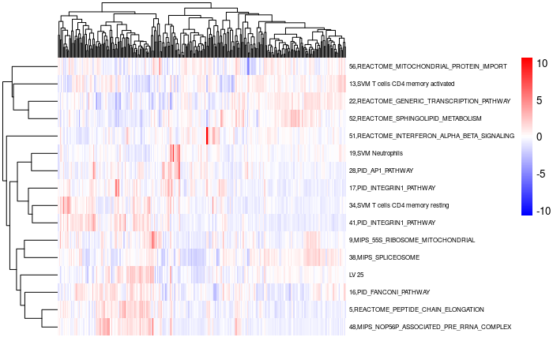

```r
pheatmap::pheatmap(sig_b_matrix,
                   color = colorRampPalette(c("blue", "white", "red"))(100),
                   scale = "row",
                   clustering_distance_cols = "correlation",
                   clustering_distance_rows = "correlation",
                   clustering_method = "average",
                   show_colnames = FALSE,
                   fontsize_row = 6)
```

Save this plot

```r
pdf(b_heatmap_file)
pheatmap::pheatmap(sig_b_matrix,
                   color = colorRampPalette(c("blue", "white", "red"))(100),
                   scale = "row",
                   clustering_distance_cols = "correlation",
                   clustering_distance_rows = "correlation",
                   clustering_method = "average",
                   show_colnames = FALSE,
                   fontsize_row = 6)
dev.off()
```